# Reproducible Research - Project 1 - Week 2

Yato

10/01/2016

## Loading and preprocessing the data

Show any code that is needed to

1. Load the data (i.e. `read.csv()`)

```r
if(!file.exists("data5")) dir.create("data5")
fileurl <- "https://d396qusza40orc.cloudfront.net/repdata%2Fdata%2Factivity.zip"
download.file(fileurl, destfile = "./data5/Factivity.zip")
unzip("./data5/Factivity.zip", exdir = "./data5")
activity <- read.csv("./data5/activity.csv")
dim(activity)
```

```
## [1] 17568     3
```

2. Process/transform the data (if necessary) into a format suitable for your analysis

```r
activity$date <- as.Date(activity$date, format="%Y-%m-%d")
```

## What is mean total number of steps taken per day?

For this part of the assignment, you can ignore the missing values in the dataset.

1. Calculate the total number of steps taken per day

```r
totalstep <- aggregate(steps ~ date, activity, sum)
```

2. If you do not understand the difference between a histogram and a barplot, research the difference between them. Make a histogram of the total number of steps taken each day

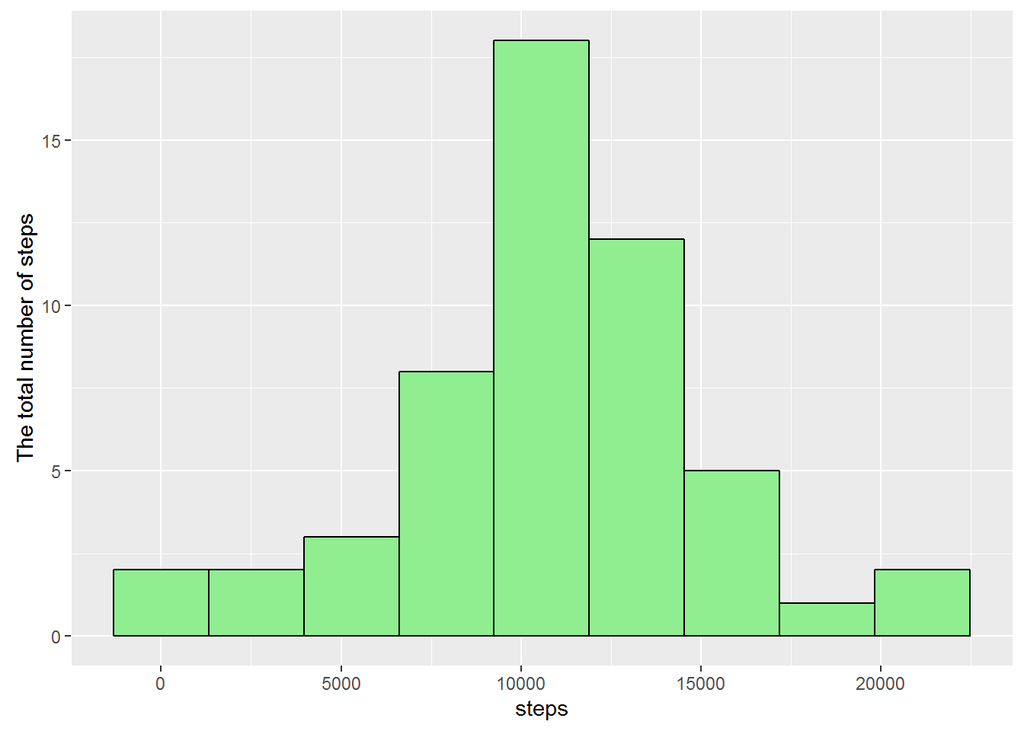

```r
binsize <- diff(range(totalstep$steps))/8
library(ggplot2)
ggplot(totalstep, aes(x=steps)) + geom_histogram(fill="lightgreen", colour = "black", binwidth = binsize) + ylab("The total number of steps")
```

3. Calculate and report the mean and median of the total number of steps taken per day What is the average daily activity pattern?

```r
meanstep <- aggregate(steps ~ date, activity, mean)
medianstep <- aggregate(steps ~ date, activity, median)
print(paste("The MEAN of the total number of steps taken on ", meanstep$date, " is ", round(meanstep$steps, 2)))
```

```
##  [1] "The MEAN of the total number of steps taken on  2012-10-02  is  0.44"
##  [2] "The MEAN of the total number of steps taken on  2012-10-03  is  39.42"
##  [3] "The MEAN of the total number of steps taken on  2012-10-04  is  42.07"
##  [4] "The MEAN of the total number of steps taken on  2012-10-05  is  46.16"
##  [5] "The MEAN of the total number of steps taken on  2012-10-06  is  53.54"
##  [6] "The MEAN of the total number of steps taken on  2012-10-07  is  38.25"
##  [7] "The MEAN of the total number of steps taken on  2012-10-09  is  44.48"
##  [8] "The MEAN of the total number of steps taken on  2012-10-10  is  34.38"
##  [9] "The MEAN of the total number of steps taken on  2012-10-11  is  35.78"
## [10] "The MEAN of the total number of steps taken on  2012-10-12  is  60.35"
## [11] "The MEAN of the total number of steps taken on  2012-10-13  is  43.15"
## [12] "The MEAN of the total number of steps taken on  2012-10-14  is  52.42"
## [13] "The MEAN of the total number of steps taken on  2012-10-15  is  35.2"
## [14] "The MEAN of the total number of steps taken on  2012-10-16  is  52.38"
## [15] "The MEAN of the total number of steps taken on  2012-10-17  is  46.71"
```

[output cut: 38 more lines]

```r
print(paste("The MEDIAN of the total number of steps taken on ", meanstep$date, " is ", round(medianstep$steps, 2)))
```

```
##  [1] "The MEDIAN of the total number of steps taken on  2012-10-02  is  0"
##  [2] "The MEDIAN of the total number of steps taken on  2012-10-03  is  0"
##  [3] "The MEDIAN of the total number of steps taken on  2012-10-04  is  0"
##  [4] "The MEDIAN of the total number of steps taken on  2012-10-05  is  0"
##  [5] "The MEDIAN of the total number of steps taken on  2012-10-06  is  0"
##  [6] "The MEDIAN of the total number of steps taken on  2012-10-07  is  0"
##  [7] "The MEDIAN of the total number of steps taken on  2012-10-09  is  0"
##  [8] "The MEDIAN of the total number of steps taken on  2012-10-10  is  0"
##  [9] "The MEDIAN of the total number of steps taken on  2012-10-11  is  0"
## [10] "The MEDIAN of the total number of steps taken on  2012-10-12  is  0"
## [11] "The MEDIAN of the total number of steps taken on  2012-10-13  is  0"
## [12] "The MEDIAN of the total number of steps taken on  2012-10-14  is  0"
## [13] "The MEDIAN of the total number of steps taken on  2012-10-15  is  0"
## [14] "The MEDIAN of the total number of steps taken on  2012-10-16  is  0"
## [15] "The MEDIAN of the total number of steps taken on  2012-10-17  is  0"
```

[output cut: 38 more lines]

## What is the average daily activity pattern?

1. Make a time series plot (i.e. type = “l”) of the 5-minute interval (x-axis) and the average number of steps taken, averaged across all days (y-axis)

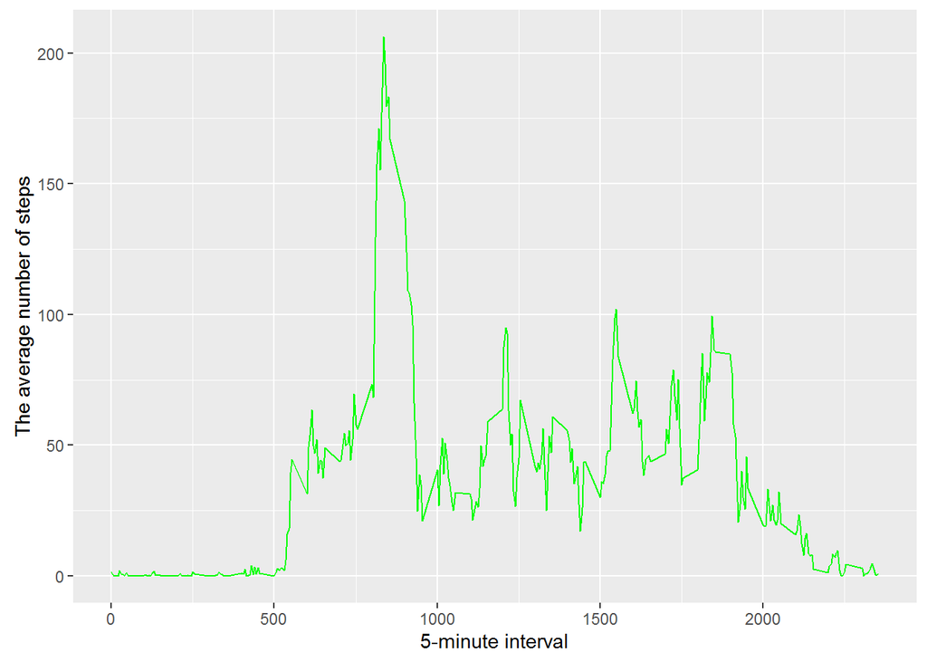

```r
interstep <- aggregate(steps ~ interval, activity, mean)
ggplot(interstep, aes(x=interval, y=steps)) + geom_line(colour="green") + xlab("5-minute interval") + ylab("The average number of steps")
```

```r
maxinterval <- interstep[which.max(interstep$steps), ]$interval
```

## Imputing missing values

Note that there are a number of days/intervals where there are missing values (coded as NA). The presence of missing days may introduce bias into some calculations or summaries of the data.

1. Calculate and report the total number of missing values in the dataset (i.e. the total number of rows with NAs)

```r
nacount <- sum(is.na(activity))
print(paste("The total number of missing vlaues is", nacount))
```

```
## [1] "The total number of missing vlaues is 2304"
```

2. Devise a strategy for filling in all of the missing values in the dataset. The strategy does not need to be sophisticated. For example, you could use the mean/median for that day, or the mean for that 5-minute interval, etc.

```r
nadata <- activity[is.na(activity$steps), ]
nadata$steps <- interstep$steps[match(nadata$interval, interstep$interval)]
```

3. Create a new dataset that is equal to the original dataset but with the missing data filled in.

```r
newactivity <- rbind(activity[!is.na(activity$steps), ], nadata)
```

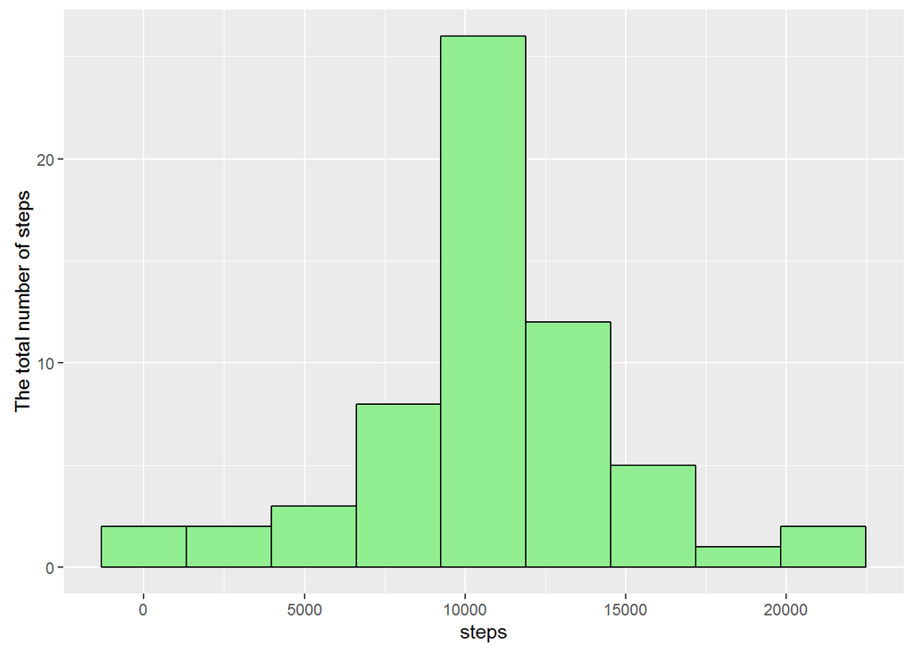

```r
# Histogram of the total number of steps taken each day after missing values are imputed
newtotstep <- aggregate(steps ~ date, newactivity, sum)
binsize <- diff(range(newtotstep$steps))/8
ggplot(newtotstep, aes(x=steps)) + geom_histogram(fill="lightgreen", colour = "black", binwidth = binsize) + ylab("The total number of steps")
```

```r
# use new dataset to calculate and report the mean and median number of steps taken each day
newmeanstep <- aggregate(steps ~ date, newactivity, mean)
newmedianstep <- aggregate(steps ~ date, newactivity, median)
print(paste("The MEAN of the total number of steps taken on ", newmeanstep$date, " is ", round(newmeanstep$steps, 2)))
```

```
##  [1] "The MEAN of the total number of steps taken on  2012-10-01  is  37.38"
##  [2] "The MEAN of the total number of steps taken on  2012-10-02  is  0.44"
##  [3] "The MEAN of the total number of steps taken on  2012-10-03  is  39.42"
##  [4] "The MEAN of the total number of steps taken on  2012-10-04  is  42.07"
##  [5] "The MEAN of the total number of steps taken on  2012-10-05  is  46.16"
##  [6] "The MEAN of the total number of steps taken on  2012-10-06  is  53.54"
##  [7] "The MEAN of the total number of steps taken on  2012-10-07  is  38.25"
##  [8] "The MEAN of the total number of steps taken on  2012-10-08  is  37.38"
##  [9] "The MEAN of the total number of steps taken on  2012-10-09  is  44.48"
## [10] "The MEAN of the total number of steps taken on  2012-10-10  is  34.38"
## [11] "The MEAN of the total number of steps taken on  2012-10-11  is  35.78"
## [12] "The MEAN of the total number of steps taken on  2012-10-12  is  60.35"
## [13] "The MEAN of the total number of steps taken on  2012-10-13  is  43.15"
## [14] "The MEAN of the total number of steps taken on  2012-10-14  is  52.42"
## [15] "The MEAN of the total number of steps taken on  2012-10-15  is  35.2"
```

[output cut: 46 more lines]

```r
print(paste("The MEDIAN of the total number of steps taken on ", newmedianstep$date, " is ", round(newmedianstep$steps, 2)))
```

```
##  [1] "The MEDIAN of the total number of steps taken on  2012-10-01  is  34.11"
##  [2] "The MEDIAN of the total number of steps taken on  2012-10-02  is  0"
##  [3] "The MEDIAN of the total number of steps taken on  2012-10-03  is  0"
##  [4] "The MEDIAN of the total number of steps taken on  2012-10-04  is  0"
##  [5] "The MEDIAN of the total number of steps taken on  2012-10-05  is  0"
##  [6] "The MEDIAN of the total number of steps taken on  2012-10-06  is  0"
##  [7] "The MEDIAN of the total number of steps taken on  2012-10-07  is  0"
##  [8] "The MEDIAN of the total number of steps taken on  2012-10-08  is  34.11"
##  [9] "The MEDIAN of the total number of steps taken on  2012-10-09  is  0"
## [10] "The MEDIAN of the total number of steps taken on  2012-10-10  is  0"
## [11] "The MEDIAN of the total number of steps taken on  2012-10-11  is  0"
## [12] "The MEDIAN of the total number of steps taken on  2012-10-12  is  0"
## [13] "The MEDIAN of the total number of steps taken on  2012-10-13  is  0"
## [14] "The MEDIAN of the total number of steps taken on  2012-10-14  is  0"
## [15] "The MEDIAN of the total number of steps taken on  2012-10-15  is  0"
```

[output cut: 46 more lines]

## Are there differences in activity patterns between weekdays and weekends?

For this part the `weekdays()` function may be of some help here. Use the dataset with the filled-in missing values for this part.

1. Create a new factor variable in the dataset with two levels – “weekday” and “weekend” indicating whether a given date is a weekday or weekend day.

```r
Sys.setlocale(category = "LC_ALL", locale = "english")
```

```
## [1] "LC_COLLATE=English_United States.1252;LC_CTYPE=English_United States.1252;LC_MONETARY=English_United States.1252;LC_NUMERIC=C;LC_TIME=English_United States.1252"
```

```r
newactivity$daytype <- factor((weekdays(newactivity$date) %in% c("Saturday", "Sunday")), labels = c("Weekend", "weekday"))
```

2. Make a panel plot containing a time series plot (i.e. type = “l”) of the 5-minute interval (x-axis) and the average number of steps taken, averaged across all weekday days or weekend days (y-axis). See the README file in the GitHub repository to see an example of what this plot should look like using simulated data.

[figure not shown]

```r
newinterstep <- aggregate(steps ~ interval + daytype, newactivity, mean)
ggplot(newinterstep, aes(x=interval, y=steps)) + geom_line(aes(color = daytype)) + facet_grid(daytype ~ .) + ylab("Number of steps") + theme(legend.position="none")
```